# Métodos estadísticos 3.11 - Ejercicio RLM

Henry Saenz - Kelly Beltrán

2023-10-25

# Douglas C. Montgomery

## 3.11 Ejercicio

Un ingeniero hizo un experimento para determinar la presión, temperatura y flujo de CO2, la humedad y el tamaño de partícula de los cacahuates sobre el rendimiento total de aceite por lote de cacahuates.

1. Ajustar un modelo de regresión lineal múltiple que relacione el rendimiento con esos regresores.
2. Probar la significancia de la regresión. ¿A qué conclusiones se puede llegar?
3. Hacer pruebas t para evaluar la contribución de cada regresor al modelo. Comentar los resultados.
4. Calcular R2 y Rldj para este modelo. Comparar esos valores con los de R2 y R2ldj para el modelo de regresión lineal múltiple, que relacione el rendimiento con la temperatura y el tamaño de partícula. Comentar los resultados.
5. Establecer un intervalo de confianza de 95% para el coeficiente de regresión de la temperatura en ambos modelos de la parte d. Comentar las diferencias encontradas.

### Datos

Se realiza el cargue de datos a trabajar.

```r
datos <- data.frame(
  "Presión" = c(415, 550, 415, 550, 415, 550, 415, 550, 415, 550, 415, 550, 415, 550, 415, 550),
  "Temp" = c(25, 25, 95, 95,25, 25, 95, 95,25, 25, 95, 95,25, 25, 95, 95),
  "Humedad" = c(5, 5, 5, 5, 15, 15, 15, 15, 5, 5, 5, 5, 15, 15, 15, 15),
  "Flujo" = c(40, 40, 40, 40, 40, 40, 40, 40, 60, 60, 60, 60, 60, 60, 60, 60),
  "Tam_particula" = c(1.28, 4.05, 4.05, 1.28, 4.05, 1.28, 1.28, 4.05, 4.05, 1.28, 1.28, 4.05, 1.28, 4.05, 4.05, 1.28),
  "Rendimiento" = c(63, 21, 36, 99, 24, 66, 71, 54, 23, 74, 80, 33, 63, 21, 44, 96))
```

### Análisis exploratorio

Comprobamos que los datos se ajusten a una distribución normal mediante el test de Shapiro-Wilk (n<50).

```
##
##  Shapiro-Wilk normality test
##
## data:  Presión
## W = 0.64396, p-value = 4.34e-05
```

```
##
##  Shapiro-Wilk normality test
##
## data:  Temp
## W = 0.64396, p-value = 4.34e-05
```

```
##
##  Shapiro-Wilk normality test
##
## data:  Humedad
## W = 0.64396, p-value = 4.34e-05
```

```
##
##  Shapiro-Wilk normality test
##
## data:  Flujo
## W = 0.64396, p-value = 4.34e-05
```

```
##
##  Shapiro-Wilk normality test
##
## data:  Tam_particula
## W = 0.64396, p-value = 4.34e-05
```

```
##
##  Shapiro-Wilk normality test
##
## data:  Rendimiento
## W = 0.92678, p-value = 0.2166
```

## Descripción gráfica de los datos

Se representan los datos mediante un diagrama de cajas y bigotes con relación a la variable “Rendimiento”

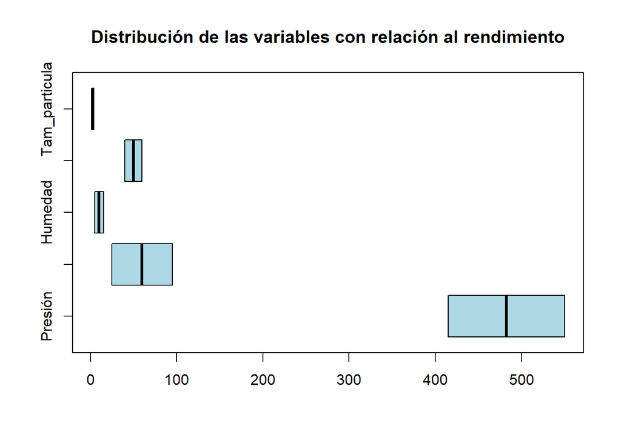

## Correlación entre las variables

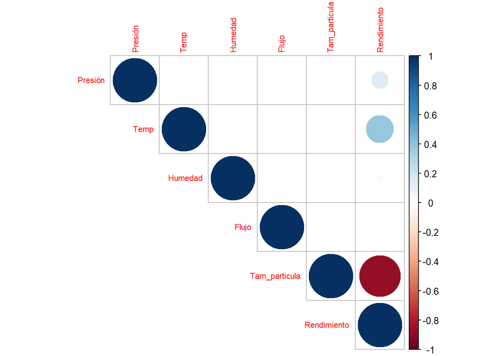

## 1. Modelo de regresión múltiple

Ajustar un modelo de regresión lineal múltiple que relacione el rendimiento con esos regresores.

```
##
## Call:
## lm(formula = Rendimiento ~ (Presión + Temp + Humedad + Flujo +
##     Tam_particula), data = datos)
##
## Residuals:
##     Min      1Q  Median      3Q     Max
## -12.250  -4.438   0.125   5.250   9.500
##
## Coefficients:
##                 Estimate Std. Error t value Pr(>|t|)
## (Intercept)    5.208e+01  1.889e+01   2.757 0.020218 *
## Presión        5.556e-02  2.987e-02   1.860 0.092544 .
## Temp           2.821e-01  5.761e-02   4.897 0.000625 ***
## Humedad        1.250e-01  4.033e-01   0.310 0.762949
## Flujo          1.776e-16  2.016e-01   0.000 1.000000
## Tam_particula -1.606e+01  1.456e+00 -11.035  6.4e-07 ***
## ---
## Signif. codes:  0 '***' 0.001 '**' 0.01 '*' 0.05 '.' 0.1 ' ' 1
##
## Residual standard error: 8.065 on 10 degrees of freedom
## Multiple R-squared:  0.9372, Adjusted R-squared:  0.9058
## F-statistic: 29.86 on 5 and 10 DF,  p-value: 1.055e-05
```

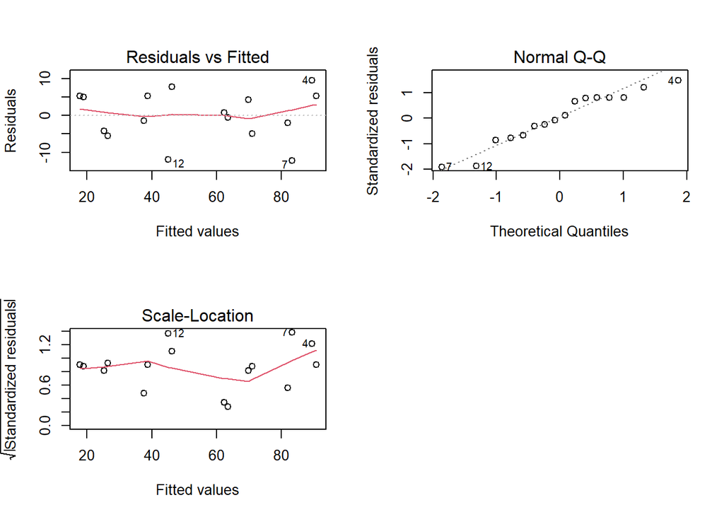

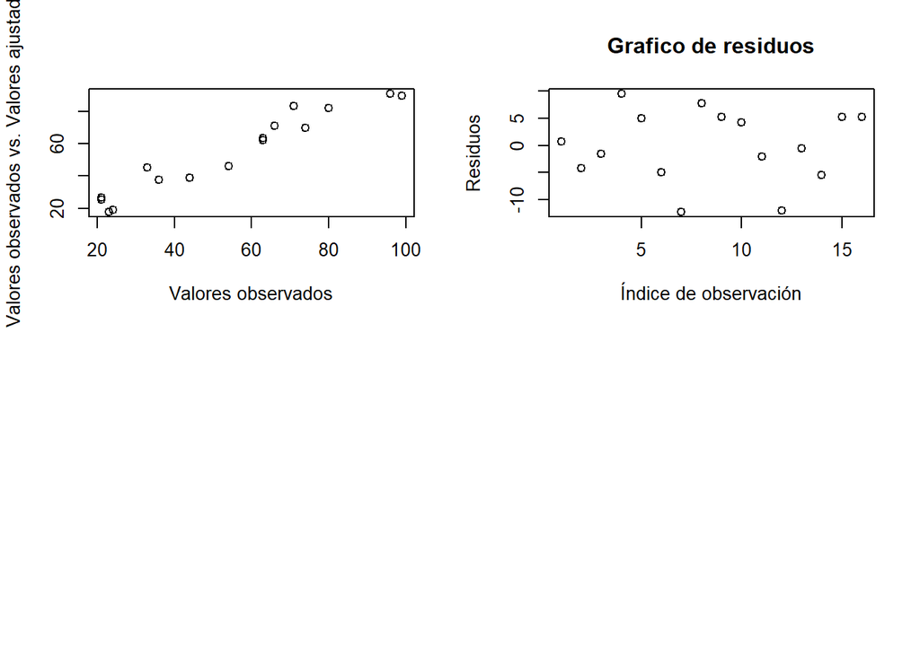

## Significancia de regresión

Probar la significancia de la regresión. ¿A qué conclusiones se puede llegar?

Los p-valores calculados para la probabilidad de significancia deben ser mayor que el estadístico F (p>F) para poder descartar significancia. Dea cuerdo a la tabla de ANOVA, se infiere que las variables Temperatura y Tamaño de particuloa tienen mayor significancia para el modelo, la variable presión con una significancia leve y las variables Humedad y Flujo con casi cero significancia para el modelo.

```
## Analysis of Variance Table
##
## Response: Rendimiento
##               Df Sum Sq Mean Sq  F value    Pr(>F)
## Presión        1  225.0   225.0   3.4589 0.0925445 .
## Temp           1 1560.2  1560.2  23.9854 0.0006254 ***
## Humedad        1    6.2     6.2   0.0961 0.7629488
## Flujo          1    0.0     0.0   0.0000 1.0000000
## Tam_particula  1 7921.0  7921.0 121.7679 6.401e-07 ***
## Residuals     10  650.5    65.1
## ---
## Signif. codes:  0 '***' 0.001 '**' 0.01 '*' 0.05 '.' 0.1 ' ' 1
```

## Pruebas t

Hacer pruebas t para evaluar la contribución de cada regresor al modelo. Comentar los resultados.

```
##   (Intercept)       Presión          Temp       Humedad         Flujo
##  5.207905e+01  5.555556e-02  2.821429e-01  1.250000e-01  1.776357e-16
## Tam_particula
## -1.606498e+01
```

## Valores de R^2

Calcular R2 y Rldj para este modelo. Comparar esos valores con los de R2 y R2ldj para el modelo de regresión lineal múltiple, que relacione el rendimiento con la temperatura y el tamaño de partícula. Comentar los resultados.

```
## [1] "El valor de R^2 para el modelo 1 es:  0.937228601756248"
## [1] "El valor de R^2 ajustada para el modelo 1 es:  0.905842902634372"
```

## Modelo 2

Se relaciona como predictores la temperatura y el tamaño inicial.

```
##
## Call:
## lm(formula = Rendimiento ~ (Temp + Tam_particula), data = datos)
##
## Residuals:
##     Min      1Q  Median      3Q     Max
## -15.375  -4.188  -0.875   3.438  12.625
##
## Coefficients:
##                Estimate Std. Error t value Pr(>|t|)
## (Intercept)    80.13461    5.69146  14.080 3.01e-09 ***
## Temp            0.28214    0.05883   4.796 0.000349 ***
## Tam_particula -16.06498    1.48659 -10.807 7.26e-08 ***
## ---
## Signif. codes:  0 '***' 0.001 '**' 0.01 '*' 0.05 '.' 0.1 ' ' 1
##
## Residual standard error: 8.236 on 13 degrees of freedom
## Multiple R-squared:  0.9149, Adjusted R-squared:  0.9018
## F-statistic: 69.89 on 2 and 13 DF,  p-value: 1.107e-07
```

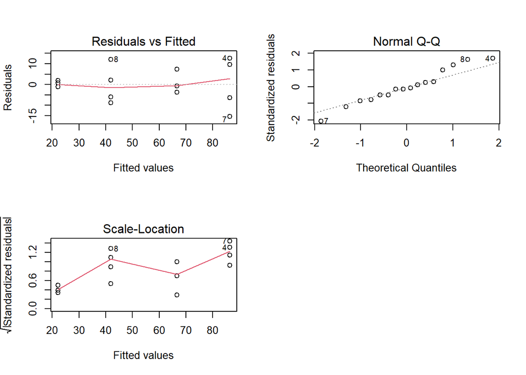

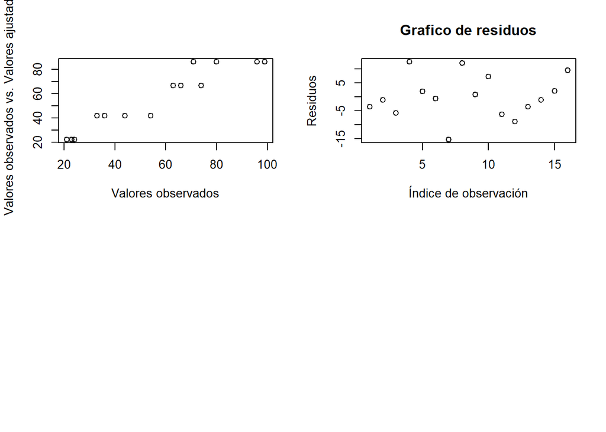

Calculamos los valores de R^2 y R^2 ajustada para el modelo 2

```
## [1] "El valor de R^2 para el modelo 2 es:  0.914913635047766"
## [1] "El valor de R^2 ajustada para el modelo 2 es:  0.901823425055114"
```

Se observa una pequeña diferencia entre los valores de R cuadrado entre ambos modelos de aproximadamente 2 puntos porcentuales. Al disminuir el numero de variables de 5 a 2, el cambio que se espera es una mayor disminucion en el R cuadrado, es decir, que existiera mayor influencia de los demás valores regresores. En cuanto al R ajustada, la diferencia porcentual es diminuta entre ambos modelos y ajusta de mayor manera en el primer modelo en contraste con el ajuste porcentual del segundo.

### Intervalo de confianza del 95%

Establecer un intervalo de confianza de 95% para el coeficiente de regresión de la temperatura en ambos modelos de la parte d. Comentar las diferencias encontradas.

```
##                      2.5 %      97.5 %
## (Intercept)     9.99688896  94.1612109
## Presión        -0.01100273   0.1221138
## Temp            0.15378045   0.4105053
## Humedad        -0.77353688   1.0235369
## Flujo          -0.44926844   0.4492684
## Tam_particula -19.30879739 -12.8211665
```

Intervalo de confianza para el modelo de regresión que involucra temperatura + tamaño de particula

```
##                     2.5 %      97.5 %
## (Intercept)    67.8389462  92.4302647
## Temp            0.1550559   0.4092298
## Tam_particula -19.2765650 -12.8533989
```